# Pulsar

2022-10-06

**Source:**

https://archive.ics.uci.edu/ml/datasets/HTRU2

Dr Robert Lyon, University of Manchester, School of Physics and Astronomy, Alan Turing Building, Manchester M13 9PL, United Kingdom, robert.lyon ‘@’ manchester.ac.uk

**About**

This is a data set which describes a sample of pulsar candidates collected during the High Time Resolution Universe Survey. Pulsars are a rare type of Neutron star that produce radio emission detectable here on Earth. They are of considerable scientific interest as probes of space-time, the inter-stellar medium, and states of matter.

**Attribute Information:**

1. MIP: Mean of the Integrated Profile
2. SDIP: Standard Deviation of the Integrated Profile
3. KIP: excess Kurtosis of the Integrated Profile
4. SIP: Skewness of the Integrated Profile
5. MDS: Mean of the DM-SNR curve
6. SDDS: Standard deviation of the DM-SNR curve
7. KDS: excess Kurtosis of the DM-SNR curve
8. SDS: Skewness of the DM-SNR curve
9. class

**Citation Request:**

If you use the dataset in your work, please cite us using the following paper:

R. J. Lyon, B. W. Stappers, S. Cooper, J. M. Brooke, J. D. Knowles, Fifty Years of Pulsar Candidate Selection: From simple filters to a new principled real-time classification approach, Monthly Notices of the Royal Astronomical Society 459 (1), 1104-1123, DOI: 10.1093/mnras/stw656

If possible, please also cite the DOI of the data set directly:

R. J. Lyon, HTRU2, DOI: 10.6084/m9.figshare.3080389.v1.

Acknowledgements

This data was obtained with the support of grant EP/I028099/1 for the University of Manchester Centre for Doctoral Training in Computer Science, from the UK Engineering and Physical Sciences Research Council (EPSRC). The raw observational data was collected by the High Time Resolution Universe Collaboration using the Parkes Observatory, funded by the Commonwealth of Australia and managed by the CSIRO.

## Attributes Details

```r
library(readxl)
library(moments)

pulsar <- read_xlsx("Pulsar_Dataset.xlsx")
options(digits = 2)
summary(pulsar)
```

```
##       MIP           SDIP         KIP            SIP          MDS
##  Min.   :  6   Min.   :25   Min.   :-1.9   Min.   :-2   Min.   :  0
##  1st Qu.:101   1st Qu.:42   1st Qu.: 0.0   1st Qu.: 0   1st Qu.:  2
##  Median :115   Median :47   Median : 0.2   Median : 0   Median :  3
##  Mean   :111   Mean   :47   Mean   : 0.5   Mean   : 2   Mean   : 13
##  3rd Qu.:127   3rd Qu.:51   3rd Qu.: 0.5   3rd Qu.: 1   3rd Qu.:  5
##  Max.   :193   Max.   :99   Max.   : 8.1   Max.   :68   Max.   :223
##       SDDS          KDS          SDS           class
##  Min.   :  7   Min.   :-3   Min.   :  -2   Min.   :0.00
##  1st Qu.: 14   1st Qu.: 6   1st Qu.:  35   1st Qu.:0.00
##  Median : 18   Median : 8   Median :  83   Median :0.00
##  Mean   : 26   Mean   : 8   Mean   : 105   Mean   :0.09
##  3rd Qu.: 28   3rd Qu.:11   3rd Qu.: 139   3rd Qu.:0.00
##  Max.   :111   Max.   :35   Max.   :1191   Max.   :1.00
```

**1) MIP**

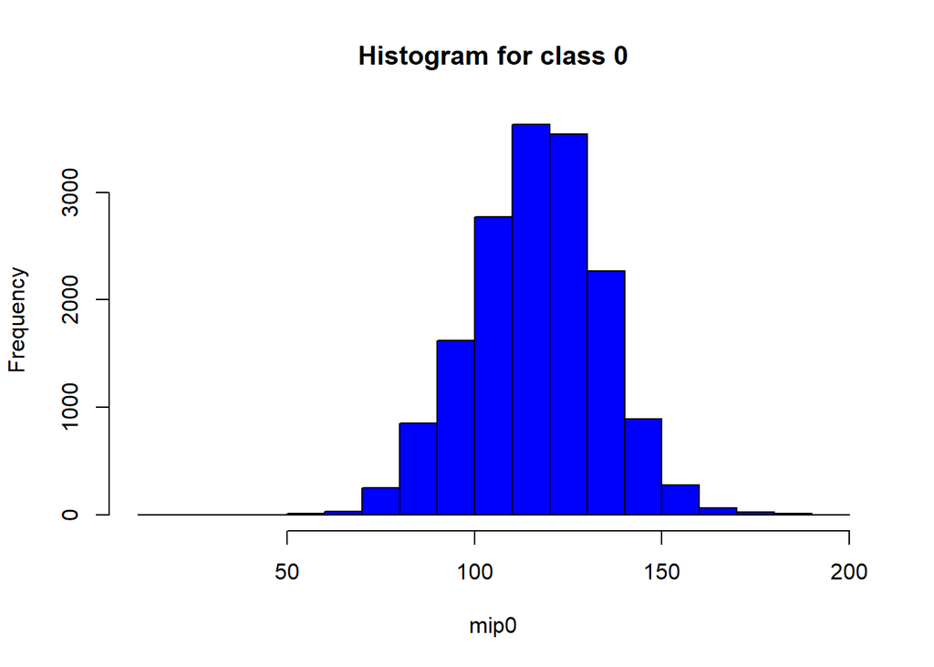

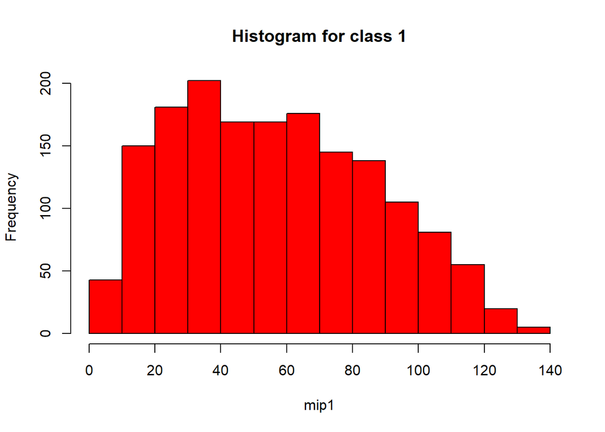

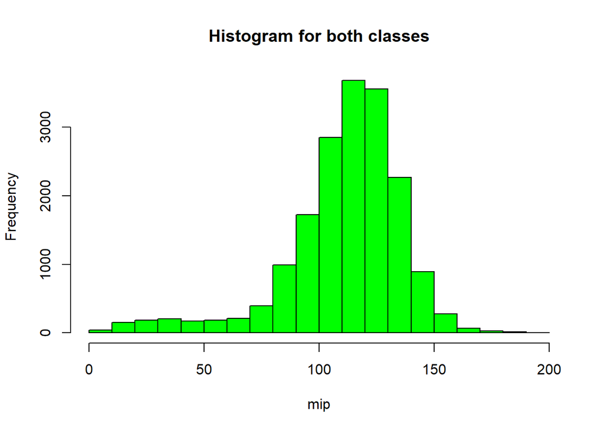

```r
class0 <- subset(pulsar,class==0)
mip0<-class0$MIP
hist(mip0, main= "Histogram for class 0", col = "blue")
class1<-subset(pulsar,class==1)
mip1<-class1$MIP
hist(mip1, main= "Histogram for class 1", col = "red")
mip<-pulsar$MIP
hist(mip, main= "Histogram for both classes", col = "green")
```

**2) SDIP**

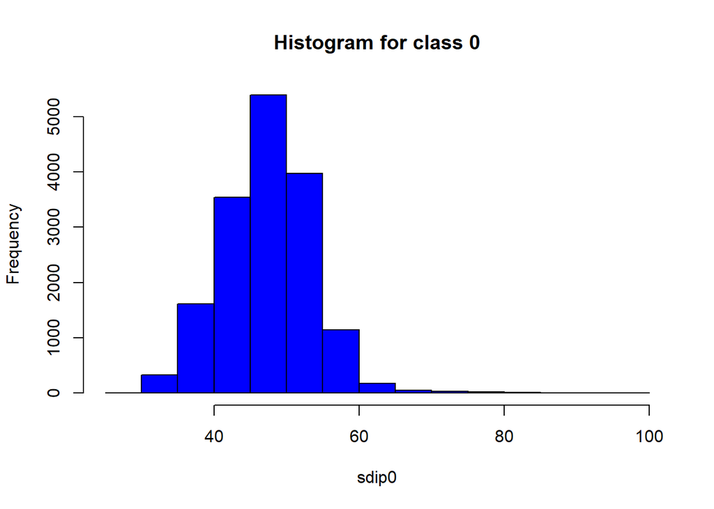

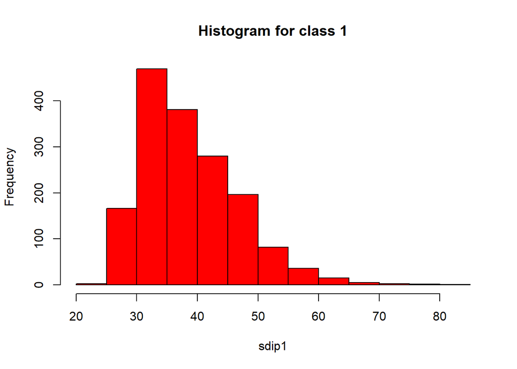

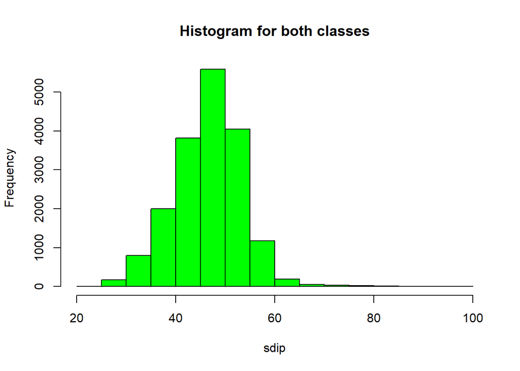

```r
class0 <- subset(pulsar,class==0)
sdip0<-class0$SDIP
hist(sdip0, main= "Histogram for class 0", col = "blue")
class1<-subset(pulsar,class==1)
sdip1<-class1$SDIP
hist(sdip1, main= "Histogram for class 1", col = "red")
sdip<-pulsar$SDIP
hist(sdip, main= "Histogram for both classes", col = "green")
```

**3) KIP**

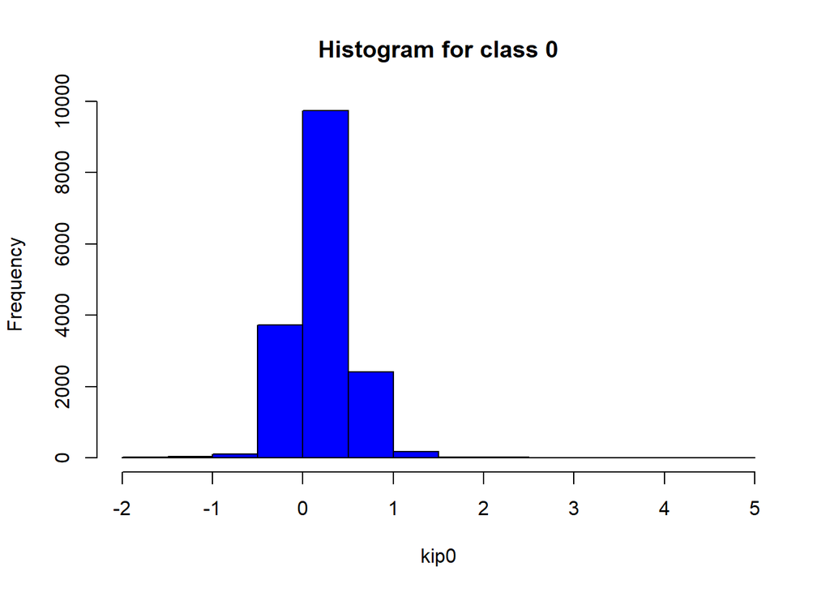

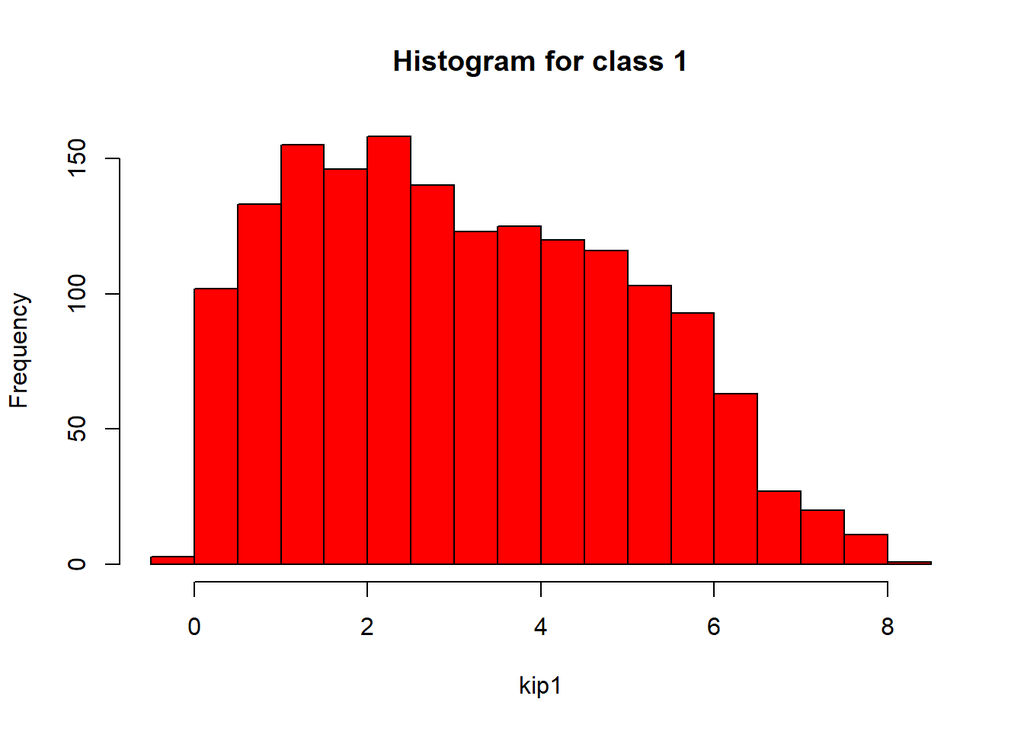

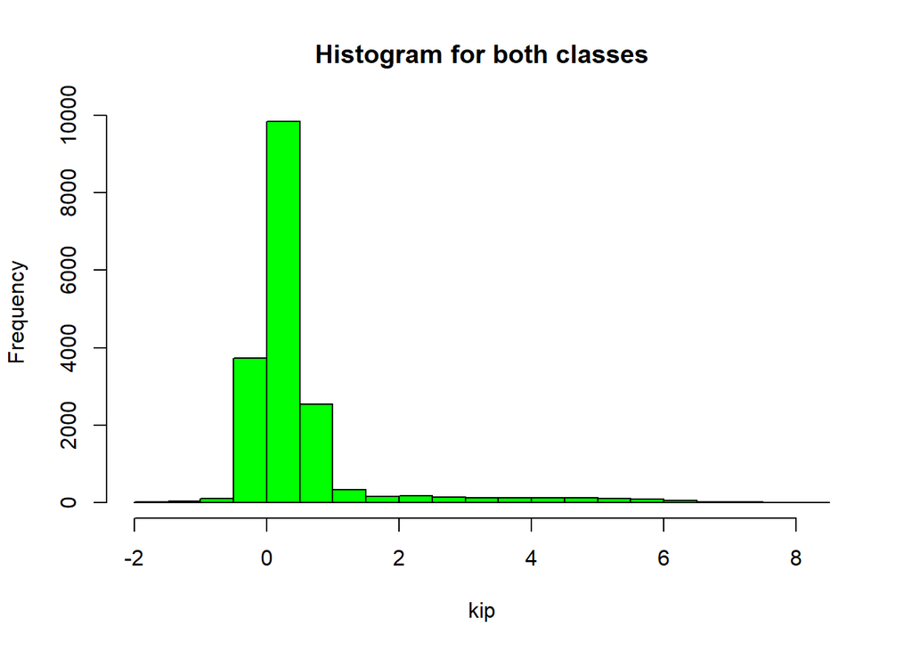

```r
class0 <- subset(pulsar,class==0)
kip0<-class0$KIP
hist(kip0, main= "Histogram for class 0", col = "blue")
class1<-subset(pulsar,class==1)
kip1<-class1$KIP
hist(kip1, main= "Histogram for class 1", col = "red")
kip<-pulsar$KIP
hist(kip, main= "Histogram for both classes", col = "green")
```

**4) SIP**

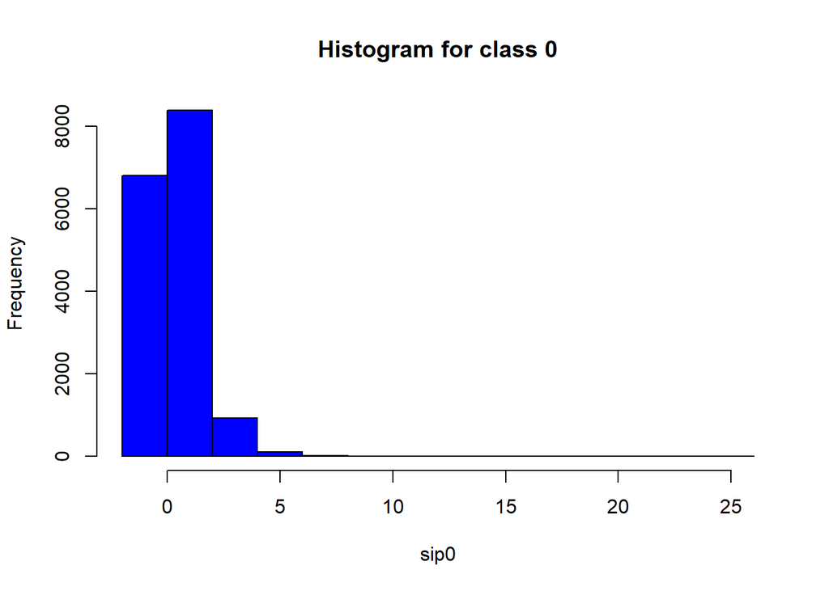

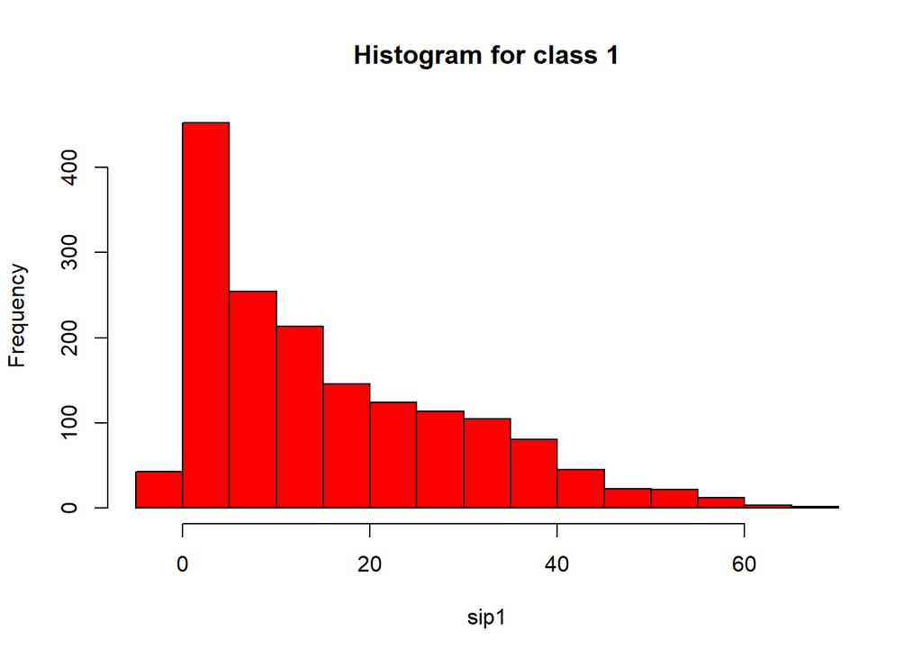

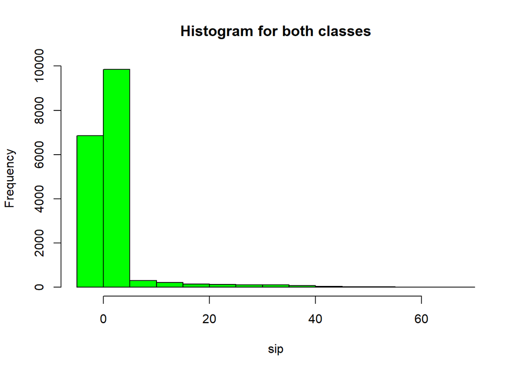

```r
class0 <- subset(pulsar,class==0)
sip0<-class0$SIP
hist(sip0, main= "Histogram for class 0", col = "blue")
class1<-subset(pulsar,class==1)
sip1<-class1$SIP
hist(sip1, main= "Histogram for class 1", col = "red")
sip<-pulsar$SIP
hist(sip, main= "Histogram for both classes", col = "green")
```

**5) MDS**

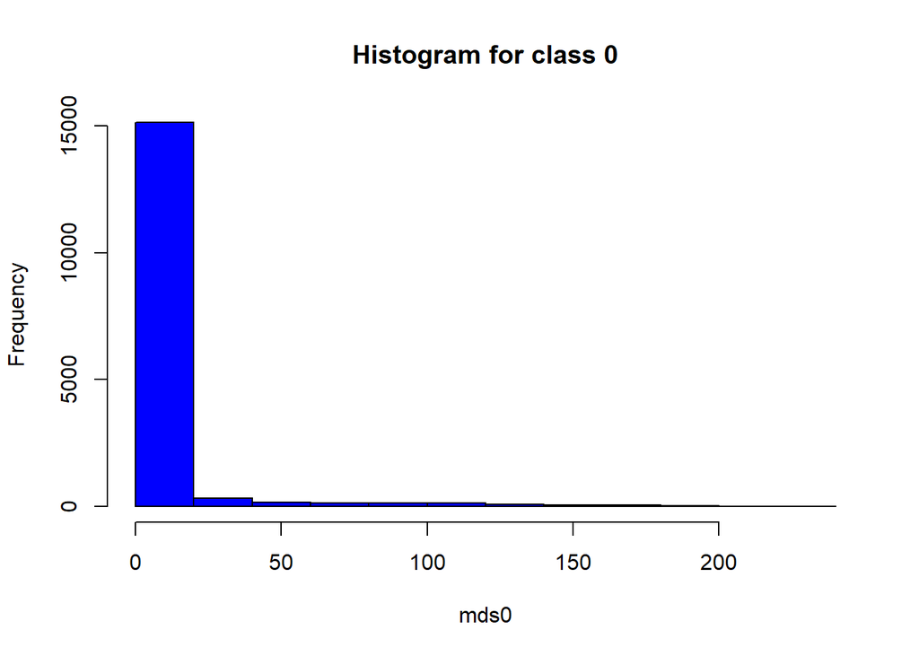

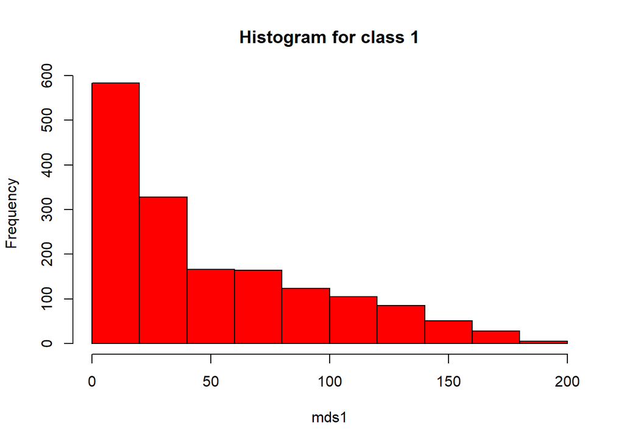

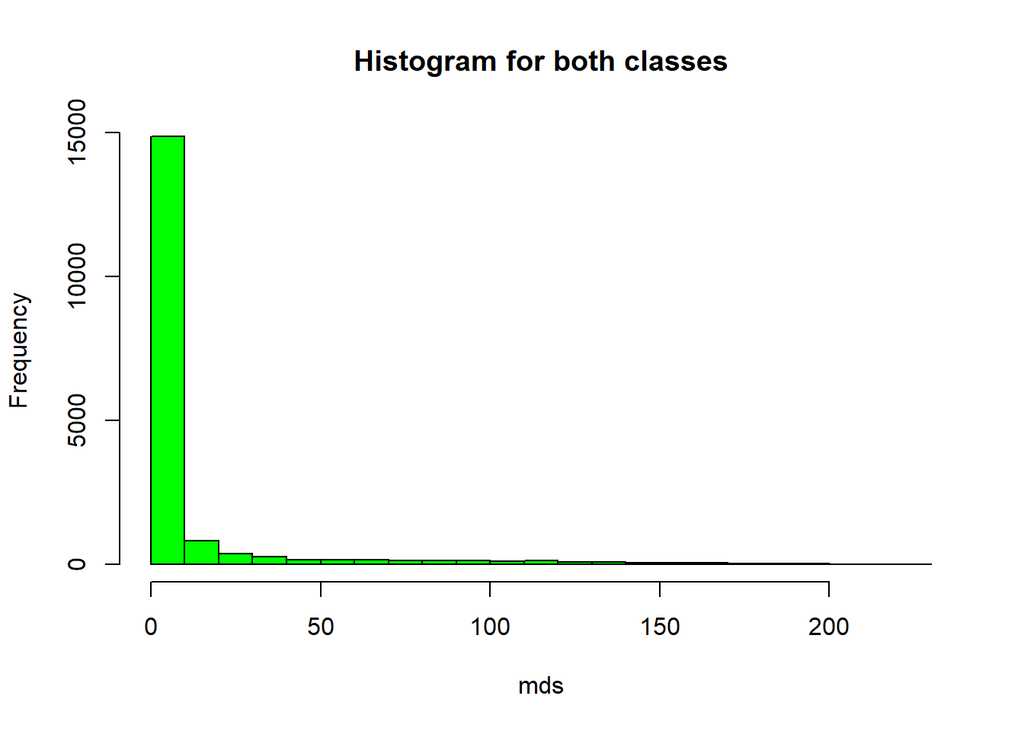

```r
class0 <- subset(pulsar,class==0)
mds0<-class0$MDS
hist(mds0, main= "Histogram for class 0", col = "blue")
class1<-subset(pulsar,class==1)
mds1<-class1$MDS
hist(mds1, main= "Histogram for class 1", col = "red")
mds<-pulsar$MDS
hist(mds, main= "Histogram for both classes", col = "green")
```

**6) SDDS**

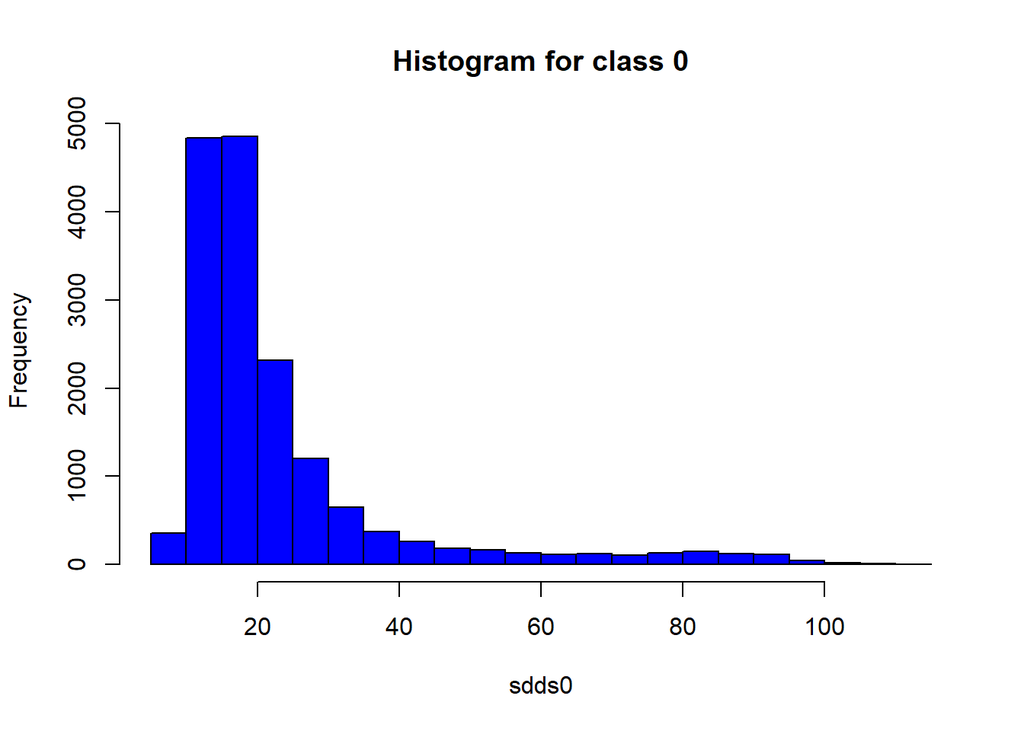

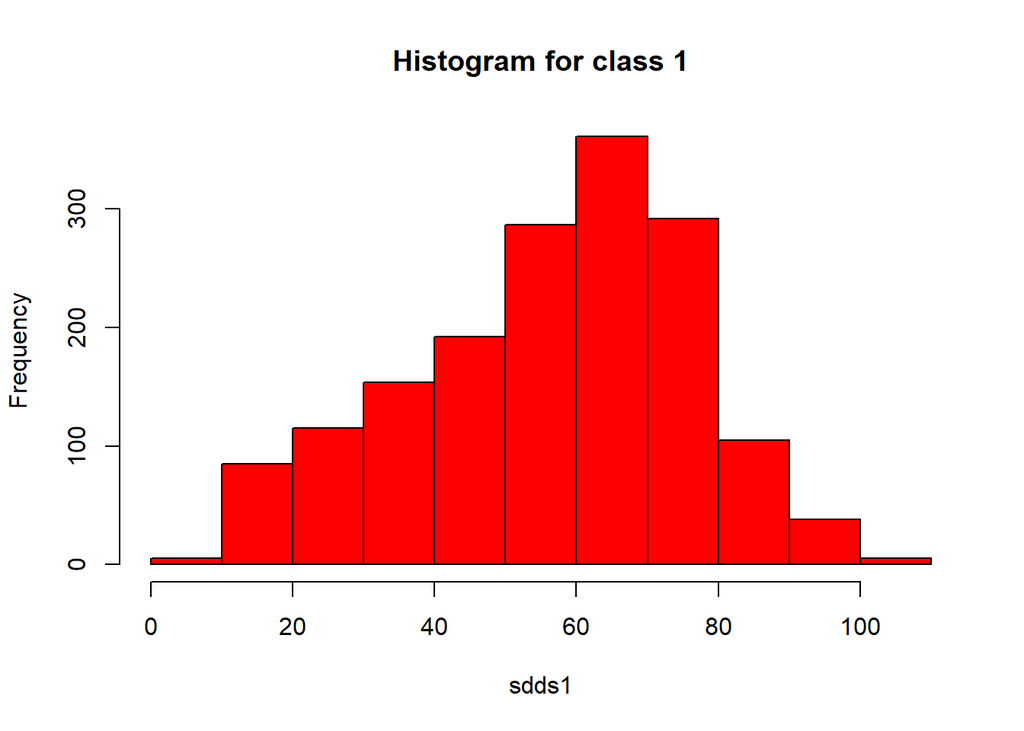

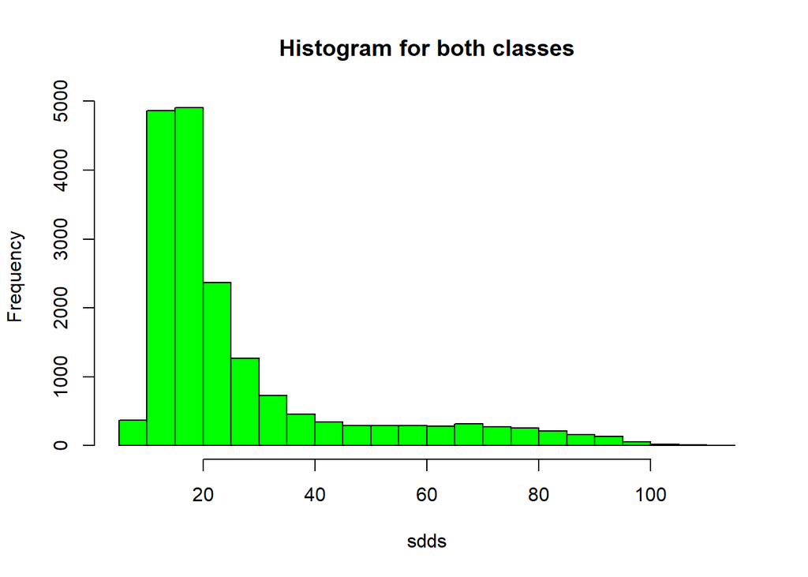

```r
class0 <- subset(pulsar,class==0)
sdds0<-class0$SDDS
hist(sdds0, main= "Histogram for class 0", col = "blue")
class1<-subset(pulsar,class==1)
sdds1<-class1$SDDS
hist(sdds1, main= "Histogram for class 1", col = "red")
sdds<-pulsar$SDDS
hist(sdds, main= "Histogram for both classes", col = "green")
```

**7) KDS**

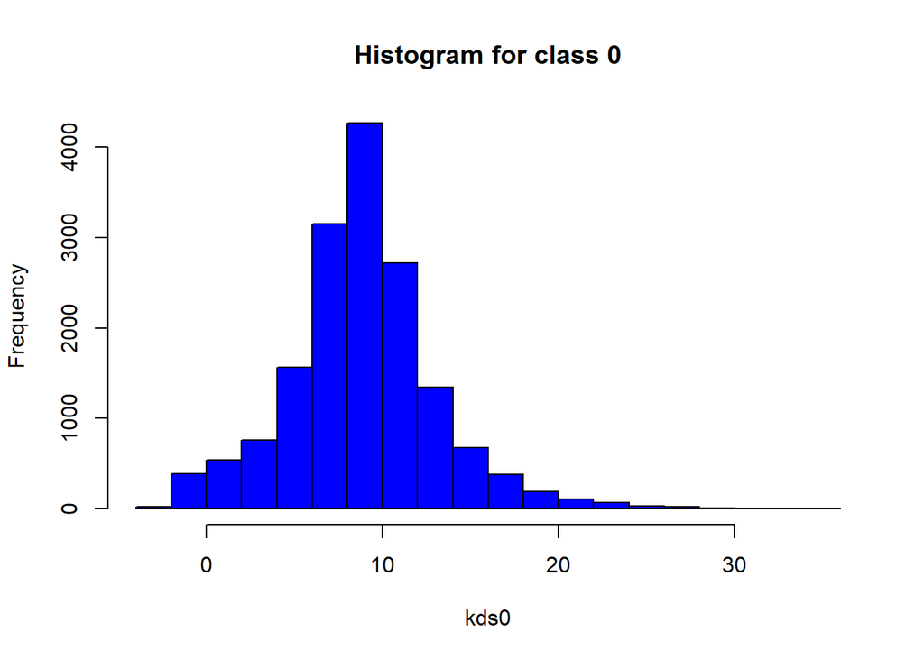

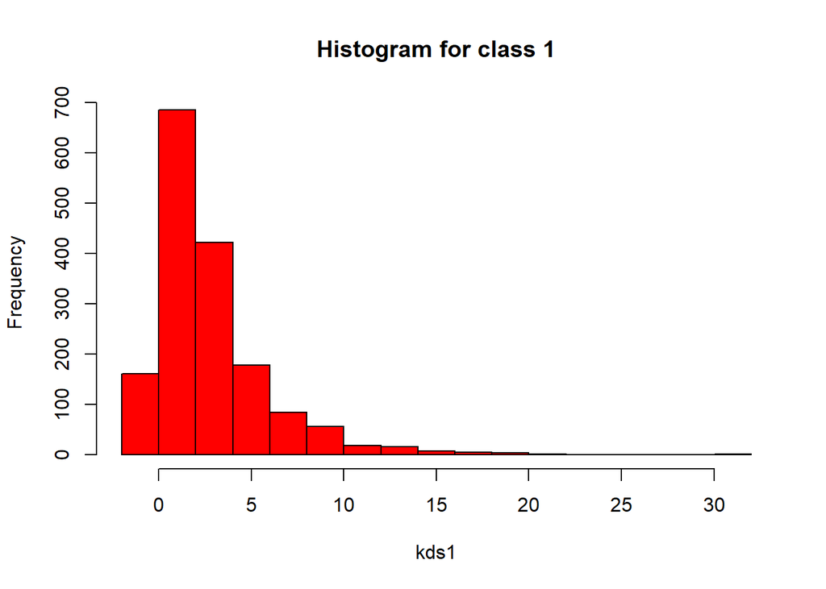

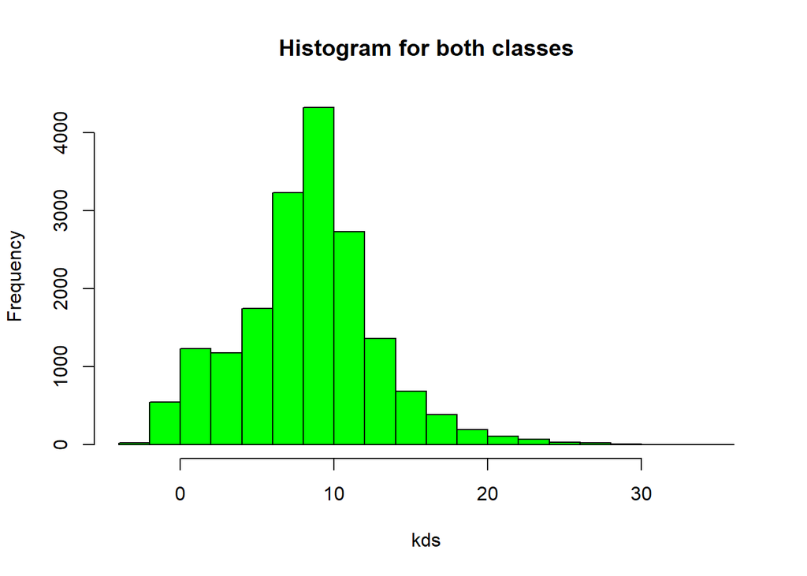

```r
class0 <- subset(pulsar,class==0)
kds0<-class0$KDS
hist(kds0, main= "Histogram for class 0", col = "blue")
class1<-subset(pulsar,class==1)
kds1<-class1$KDS
hist(kds1, main= "Histogram for class 1", col = "red")
kds<-pulsar$KDS
hist(kds, main= "Histogram for both classes", col = "green")
```

**8) SDS**

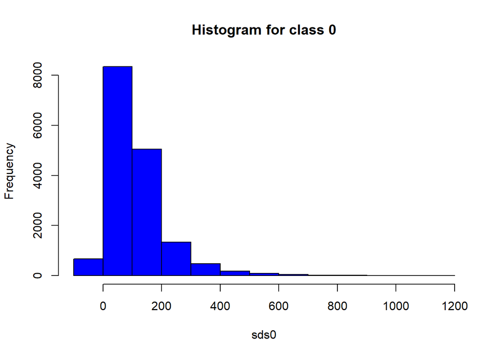

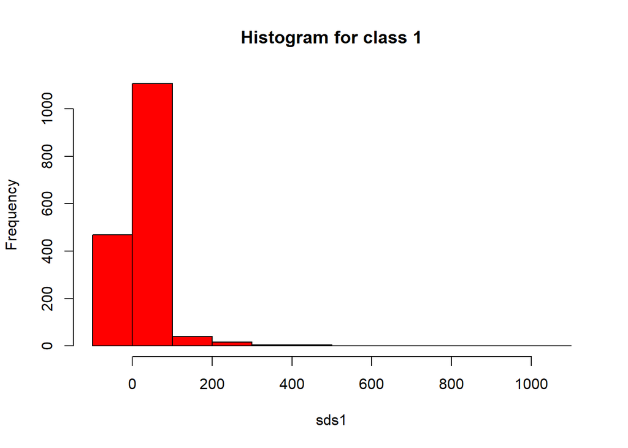

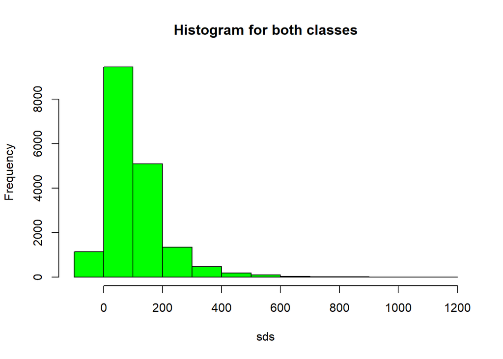

```r
class0 <- subset(pulsar,class==0)
sds0<-class0$SDS
hist(sds0, main= "Histogram for class 0", col = "blue")
class1<-subset(pulsar,class==1)
sds1<-class1$SDS
hist(sds1, main= "Histogram for class 1", col = "red")
sds<-pulsar$SDS
hist(sds, main= "Histogram for both classes", col = "green")
```

## Correlation Matrix

**Class 0**

```r
options(digits = 2)
co0<-subset(pulsar,class==0)
cor(co0[-9])
```

```
##         MIP   SDIP    KIP    SIP    MDS   SDDS    KDS    SDS
## MIP   1.000  0.412 -0.850 -0.567  0.117  0.134 -0.118 -0.078
## SDIP  0.412  1.000 -0.393 -0.742  0.235  0.206 -0.164 -0.093
## KIP  -0.850 -0.393  1.000  0.635 -0.104 -0.106  0.092  0.057
## SIP  -0.567 -0.742  0.635  1.000 -0.046 -0.061  0.062  0.042
## MDS   0.117  0.235 -0.104 -0.046  1.000  0.776 -0.553 -0.300
## SDDS  0.134  0.206 -0.106 -0.061  0.776  1.000 -0.770 -0.542
## KDS  -0.118 -0.164  0.092  0.062 -0.553 -0.770  1.000  0.930
## SDS  -0.078 -0.093  0.057  0.042 -0.300 -0.542  0.930  1.000
```

```r
cov(co0[-9])
```

```
##         MIP   SDIP   KIP    SIP     MDS    SDDS    KDS     SDS
## MIP   305.4  44.51 -4.97 -10.19   50.06   38.96  -8.77  -146.1
## SDIP   44.5  38.23 -0.81  -4.72   35.52   21.24  -4.29   -61.1
## KIP    -5.0  -0.81  0.11   0.22   -0.85   -0.59   0.13     2.0
## SIP   -10.2  -4.72  0.22   1.06   -1.17   -1.04   0.27     4.6
## MDS    50.1  35.52 -0.85  -1.17  595.92  315.52 -57.18  -782.8
## SDDS   39.0  21.24 -0.59  -1.04  315.52  277.27 -54.34  -963.2
## KDS    -8.8  -4.29  0.13   0.27  -57.18  -54.34  17.97   420.8
## SDS  -146.1 -61.10  2.03   4.57 -782.84 -963.20 420.80 11389.6
```

```r
det(cor(co0[-9]))
```

```
## [1] 0.00049
```

```r
det(cov(co0[-9]))
```

```
## [1] 2.3e+10
```

```r
eigen(cor(co0[-9]))
```

```
## eigen() decomposition
## $values
## [1] 3.317 2.471 0.883 0.791 0.223 0.176 0.122 0.018
##
## $vectors
##       [,1]  [,2]  [,3]  [,4]    [,5]   [,6]    [,7]     [,8]
## [1,] -0.33  0.39 -0.27 -0.39  0.4648  0.169 -0.5214 -0.00436
## [2,] -0.33  0.29  0.42  0.51  0.5252  0.040  0.3022 -0.00794
## [3,]  0.32 -0.41  0.27  0.36  0.2258  0.174 -0.6638  0.00099
## [4,]  0.31 -0.43 -0.11 -0.36  0.6453  0.024  0.3970 -0.00217
## [5,] -0.35 -0.25  0.53 -0.38 -0.0008 -0.592 -0.1596 -0.08527
## [6,] -0.41 -0.32  0.24 -0.21 -0.1905  0.731  0.1121 -0.21246
## [7,]  0.42  0.36  0.26 -0.16 -0.0074  0.038  0.0016 -0.77467
## [8,]  0.35  0.33  0.50 -0.33 -0.0660  0.230  0.0222  0.58939
```

```r
eigen(cov(co0[-9]))
```

```
## eigen() decomposition
## $values
## [1] 1.2e+04 6.8e+02 3.0e+02 6.5e+01 3.0e+01 5.3e-01 3.7e-01 2.5e-02
##
## $vectors
##          [,1]    [,2]     [,3]     [,4]     [,5]    [,6]     [,7]     [,8]
## [1,] -0.01358  0.1316  0.97876  0.01594 -0.15383  0.0010 -0.02039  1.3e-02
## [2,] -0.00572  0.0628  0.14309  0.03130  0.98128  0.0034 -0.10738 -1.1e-02
## [3,]  0.00019 -0.0022 -0.01597 -0.00092 -0.00049 -0.0024 -0.12608  9.9e-01
## [4,]  0.00042 -0.0039 -0.03453 -0.00180 -0.10379 -0.0247 -0.98567 -1.3e-01
## [5,] -0.07372  0.8722 -0.13379  0.46149 -0.05100  0.0191  0.00512  9.2e-04
## [6,] -0.08712  0.4518 -0.04685 -0.88375  0.00523  0.0709 -0.00084 -4.8e-04
## [7,]  0.03701 -0.0461  0.00351  0.05253 -0.00519  0.9966 -0.02432 -7.3e-04
## [8,]  0.99267  0.1083  0.00005 -0.04484  0.00046 -0.0295  0.00076  3.8e-05
```

**Class 1**

```r
options(digits = 2)
co1<-subset(pulsar,class==1)
cor(co1[-9])
```

```
##        MIP   SDIP   KIP   SIP    MDS  SDDS   KDS   SDS
## MIP   1.00  0.573 -0.93 -0.83 -0.542 -0.43  0.54  0.36
## SDIP  0.57  1.000 -0.70 -0.74 -0.044 -0.13  0.19  0.19
## KIP  -0.93 -0.699  1.00  0.97  0.492  0.43 -0.51 -0.33
## SIP  -0.83 -0.739  0.97  1.00  0.418  0.35 -0.42 -0.27
## MDS  -0.54 -0.044  0.49  0.42  1.000  0.70 -0.70 -0.36
## SDDS -0.43 -0.126  0.43  0.35  0.702  1.00 -0.86 -0.60
## KDS   0.54  0.185 -0.51 -0.42 -0.703 -0.86  1.00  0.86
## SDS   0.36  0.187 -0.33 -0.27 -0.355 -0.60  0.86  1.00
```

```r
cov(co1[-9])
```

```
##       MIP  SDIP   KIP  SIP  MDS SDDS   KDS  SDS
## MIP   900 138.0 -52.4 -350 -736 -256  50.8  542
## SDIP  138  64.5 -10.5  -83  -16  -20   4.6   76
## KIP   -52 -10.5   3.5   25   42   16  -3.0  -32
## SIP  -350 -83.1  25.4  196  265   97 -18.4 -196
## MDS  -736 -16.1  41.7  265 2051  627 -98.9 -819
## SDDS -256 -19.9  15.8   97  627  389 -52.7 -601
## KDS    51   4.6  -3.0  -18  -99  -53   9.6  137
## SDS   542  76.4 -31.7 -196 -819 -601 136.5 2590
```

```r
det(cor(co1[-9]))
```

```
## [1] 7.7e-06
```

```r
det(cov(co1[-9]))
```

```
## [1] 6.1e+12
```

```r
eigen(cor(co1[-9]))
```

```
## eigen() decomposition
## $values
## [1] 4.705 1.853 0.762 0.330 0.191 0.131 0.020 0.007
##
## $vectors
##       [,1]  [,2]   [,3]   [,4]   [,5]   [,6]   [,7]    [,8]
## [1,] -0.40  0.22  0.170 -0.432 -0.217  0.646  0.112  0.3101
## [2,] -0.27  0.47 -0.383  0.566  0.395  0.291 -0.018 -0.0022
## [3,]  0.41 -0.30 -0.096  0.165  0.189  0.167  0.054  0.7972
## [4,]  0.39 -0.36 -0.054  0.030  0.089  0.673 -0.018 -0.5085
## [5,]  0.32  0.28 -0.606 -0.059 -0.642  0.025 -0.178  0.0365
## [6,]  0.34  0.39 -0.084 -0.587  0.548 -0.056 -0.276 -0.0138
## [7,] -0.38 -0.39 -0.174 -0.041  0.038  0.031 -0.815  0.0776
## [8,] -0.29 -0.36 -0.638 -0.338  0.196 -0.109  0.461 -0.0468
```

```r
eigen(cov(co1[-9]))
```

```
## eigen() decomposition
## $values
## [1] 3.8e+03 1.6e+03 6.5e+02 1.3e+02 6.3e+01 1.8e+01 2.8e-01 3.8e-02
##
## $vectors
##        [,1]     [,2]    [,3]   [,4]   [,5]    [,6]    [,7]    [,8]
## [1,] -0.317 -2.4e-01  0.7968 -0.032 -0.447 -0.0602  0.0125  0.0243
## [2,] -0.033 -2.1e-05  0.2168  0.095  0.513 -0.8241 -0.0086  0.0018
## [3,]  0.019  1.4e-02 -0.0505 -0.011 -0.049 -0.0439  0.0504  0.9950
## [4,]  0.119  9.6e-02 -0.3686 -0.091 -0.716 -0.5588 -0.0011 -0.0829
## [5,]  0.577  6.6e-01  0.3949  0.247 -0.091  0.0530 -0.0149  0.0015
## [6,]  0.258  5.8e-02  0.1427 -0.946  0.108 -0.0140 -0.0530 -0.0019
## [7,] -0.049  8.3e-03 -0.0095  0.040 -0.015  0.0049 -0.9965  0.0507
## [8,] -0.695  7.0e-01 -0.0578 -0.155  0.021  0.0075  0.0337 -0.0019
```

**Both Classes**

```r
options(digits = 2)
cor(pulsar[-9])
```

```
##        MIP    SDIP   KIP   SIP     MDS   SDDS    KDS    SDS
## MIP   1.00  0.5471 -0.87 -0.74 -0.2988 -0.307  0.234  0.144
## SDIP  0.55  1.0000 -0.52 -0.54  0.0069 -0.048  0.029  0.028
## KIP  -0.87 -0.5214  1.00  0.95  0.4144  0.433 -0.341 -0.214
## SIP  -0.74 -0.5398  0.95  1.00  0.4121  0.415 -0.329 -0.205
## MDS  -0.30  0.0069  0.41  0.41  1.0000  0.797 -0.616 -0.354
## SDDS -0.31 -0.0476  0.43  0.42  0.7966  1.000 -0.810 -0.576
## KDS   0.23  0.0294 -0.34 -0.33 -0.6160 -0.810  1.000  0.924
## SDS   0.14  0.0277 -0.21 -0.20 -0.3543 -0.576  0.924  1.000
```

```r
cov(pulsar[-9])
```

```
##       MIP   SDIP   KIP    SIP     MDS    SDDS    KDS   SDS
## MIP   658  96.05 -23.9 -116.9  -225.9  -153.3  27.09   394
## SDIP   96  46.83  -3.8  -22.8     1.4    -6.3   0.91    20
## KIP   -24  -3.80   1.1    6.2    13.0     9.0  -1.64   -24
## SIP  -117 -22.78   6.2   38.0    74.9    49.9  -9.14  -135
## MDS  -226   1.39  13.0   74.9   868.7   457.1 -81.81 -1112
## SDDS -153  -6.35   9.0   49.9   457.1   379.1 -71.05 -1194
## KDS    27   0.91  -1.6   -9.1   -81.8   -71.0  20.30   443
## SDS   394  20.18 -24.3 -134.5 -1112.2 -1194.2 443.36 11345
```

```r
det(cor(pulsar[-9]))
```

```
## [1] 4.4e-05
```

```r
det(cov(pulsar[-9]))
```

```
## [1] 4.5e+12
```

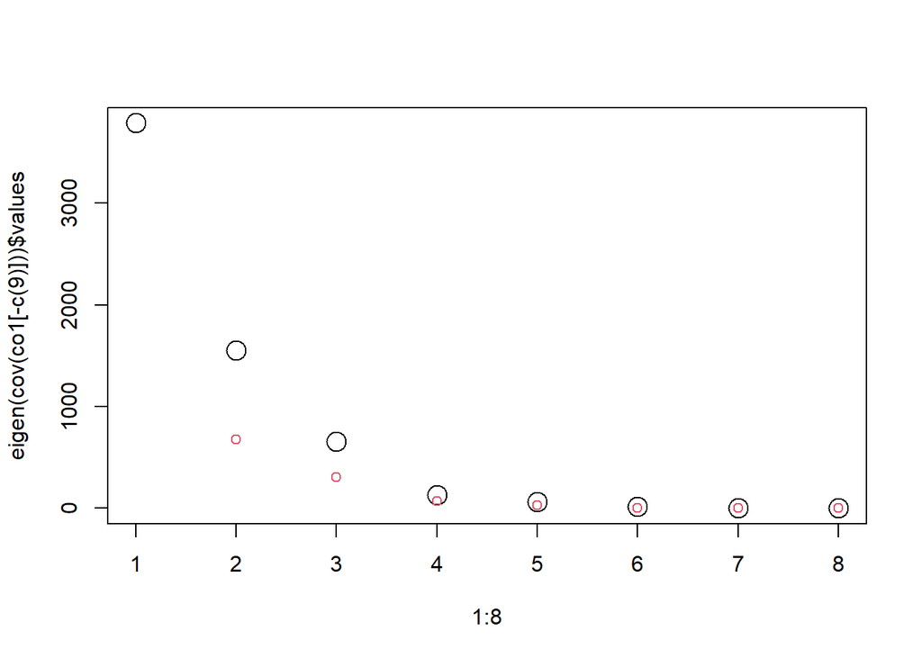

```r
plot(1:8, eigen(cov(co1[-c(9)]))$values, cex=2)
points(1:8, eigen(cov(co0[-c(9)]))$values, col=2)
```